# SWORD – Quick-Start Guide

# SWORD & TORS – Quick-Start Guide

> **SWORD** = **S**upport vector machine **W**eighted **O**blique **R**andom **D**ecision forests **TORS** = **T**ree via **O**blique **R**egression with **S**VM

This document explains the main R functions provided in `SWORD_functions/`, shows how to call them, and describes every parameter. The companion script `quick_test_SWORD_TORS.R` runs a fully self-contained example on a simulated dataset.

## Table of Contents

1. Overview
2. Required Packages
3. Function Reference
   - SWORD – fit the forest
   - TORS – fit a single tree
   - Prediction functions
   - Variable Importance – VI_SWORD
   - Utilities
4. Quick-Start Example
5. Parameter Tuning Guide
6. Output Structure

## Overview

SWORD is an **oblique random forest for regression**. At each internal node, a split is defined by a linear combination of predictors rather than a single feature threshold. The linear coefficients are obtained from a **Weighted Support Vector Machine (W-SVM)** with a linear kernel, where observation weights reflect how informative each point is for the local split.

```
Forest (SWORD)
 `--> m bootstrap trees  -->  TORS (single oblique regression tree)
                                `--> each node split: W-SVM linear combination
                                       `--> weights: "scale" (mean/sd) or "robust" (median/MAD)
```

**Key ideas:**

| Concept | Description |
| --- | --- |
| Oblique split | Split hyperplane = linear combination of selected predictors |
| Feature selection per split | Only the top-`rf_var` predictors by correlation/MI to the response are considered |
| Observation weighting | Each sample gets a weight based on its residual – emphasises hard-to-fit observations |
| Variable importance | OIW-VI: aggregates the absolute SVM coefficients weighted by node impurity reduction |

## Required Packages

```r
install.packages(c("data.table", "infotheo", "WeightSVM",
                   "data.tree", "randomForest", "ggplot2"))
```

| Package | Role |
| --- | --- |
| `WeightSVM` | Fits the weighted SVM at each internal node |
| `data.tree` | Stores and traverses the oblique tree structure |
| `infotheo` | Mutual information computation (when `relation = "MI"`) |
| `data.table` | Fast data manipulation inside the forest |

Load the functions with:

```r
source("SWORD_functions/SWORD_Functions_ADAC.R")
```

## Function Reference

### SWORD – fit the forest

```r
SWORD(
  Covariates,
  y,
  nmin          = 5,
  minleaf       = 2,
  cp            = 0.0,
  n_perc        = 1,
  n_topCor      = 2,
  threshold_COR = 1,
  m             = 10,
  rf_var        = ncol(Covariates),
  rand_ntopcor  = TRUE,
  relation      = "Pearson",
  Weight_Scheme = "scale",
  type_of_svm   = "C-classification",
  cost_C        = 1,
  cost_nu       = 0.5,
  seed_BS       = 25,
  parallel      = FALSE,
  chunk         = FALSE,
  n_chunks      = NULL,
  OOB           = TRUE,
  n_workers     = 1,
  verbose       = FALSE,
  timeout_tree  = 300
)
```

#### Parameters

| Parameter | Type | Default | Description |
| --- | --- | --- | --- |
| `Covariates` | `data.frame` | – | Predictor matrix (numeric columns) |
| `y` | `numeric` | – | Response vector (same length as `nrow(Covariates)`) |
| `nmin` | `integer` | `5` | Minimum node size to attempt a split; nodes with fewer observations become leaves |
| `minleaf` | `integer` | `2` | Minimum number of observations allowed in each child node after a split |
| `cp` | `numeric` | `0.0` | Complexity parameter: a split is accepted only if it reduces node deviance by at least `cp x root_deviance`. Set `0` to grow full trees |
| `n_perc` | `integer` | `1` | Number of quantile thresholds evaluated per candidate split direction |
| `n_topCor` | `integer` | `2` | Base cardinality of the feature subset used to define each oblique split (see also `rand_ntopcor`) |
| `threshold_COR` | `numeric` | `1` | Minimum absolute correlation (or MI) required for a feature to enter the split candidate pool. `1` keeps all features; lower values pre-filter weakly correlated ones |
| `m` | `integer` | `10` | Number of trees in the forest |
| `rf_var` | `integer` | `ncol(Covariates)` | Number of predictors considered at each node before the W-SVM step. Default uses all features; set to `ceil(p/3)` for stronger randomisation (classic RF style) |
| `rand_ntopcor` | `logical` | `TRUE` | If `TRUE`, the cardinality of the top-correlated subset is drawn uniformly in `[1, ncol()]` at each node (adds randomness); if `FALSE`, always uses exactly `n_topCor` features |
| `relation` | `character` | `"Pearson"` | Dependency measure for feature ranking: `"Pearson"` (absolute Pearson correlation) or `"MI"` (mutual information via `infotheo`) |
| `Weight_Scheme` | `character` | `"scale"` | Observation weighting scheme fed to the W-SVM: `"scale"` uses mean/sd of residuals; `"robust"` uses median/MAD (better with outliers) |
| `type_of_svm` | `character` | `"C-classification"` | SVM formulation: `"C-classification"` (cost parameter `cost_C`) or `"nu-classification"` (parameter `cost_nu`) |
| `cost_C` | `numeric` | `1` | SVM cost `C` when `type_of_svm = "C-classification"` |
| `cost_nu` | `numeric` | `0.5` | SVM `nu` when `type_of_svm = "nu-classification"` |
| `seed_BS` | `integer` | `25` | Seed offset for bootstrap sampling: tree `i` uses `set.seed(i + seed_BS)` |
| `parallel` | `logical` | `FALSE` | Enable parallel tree construction via `furrr`/`future` |
| `chunk` | `logical` | `FALSE` | Split the `m` trees into chunks before parallelising (reduces memory overhead) |
| `n_chunks` | `integer\\|NULL` | `NULL` | Number of chunks when `chunk = TRUE`; `NULL` = auto |
| `OOB` | `logical` | `TRUE` | Compute out-of-bag predictions and error metrics (RMSE, MSE, MAE, R^2) |
| `n_workers` | `integer` | `1` | Number of parallel workers (only used when `parallel = TRUE`) |
| `verbose` | `logical` | `FALSE` | Print tree index to console during sequential runs |
| `timeout_tree` | `numeric\\|NULL` | `300` | Maximum seconds allowed per tree; trees that exceed the limit are skipped and flagged. Set `NULL` to disable |

#### Returns

A named list:

[output not shown]

> OOB metrics are only present when `OOB = TRUE` and at least one tree was fitted successfully.

### TORS – fit a single tree

```r
TORS(
  Covariates,
  y,
  nmin          = 5,
  minleaf       = round(nmin / 3),
  cp            = 0.0,
  n_perc        = 1,
  n_topCor      = 2,
  threshold_COR = 1,
  rf_var        = ncol(Covariates),
  rand_ntopcor  = FALSE,
  relation      = "Pearson",
  Weight_Scheme = "scale",
  type_of_svm   = "C-classification",
  cost_C        = 1,
  cost_nu       = 0.5
)
```

Parameters are identical to `SWORD` (forest-specific options like `m`, `OOB`, `parallel`, etc. do not apply). Key differences from the forest call:

| Parameter | Single tree default | Forest default | Reason |
| --- | --- | --- | --- |
| `rf_var` | `ncol(Covariates)` (all features) | `ncol(Covariates)` | All features considered at each node (paper default) |
| `rand_ntopcor` | `FALSE` | `TRUE` | Deterministic split for a standalone tree |

#### Returns

A `data.tree` Node object representing the fitted oblique regression tree. Each internal node stores the W-SVM split coefficients; each leaf stores the mean response of its training observations.

> **Reference:** Carta, A., Frigau, L. (2025). Tree oblique for regression with weighted support vector machine. *Computational Statistics*, 40, 5257–5291. https://doi.org/10.1007/s00180-025-01647-w

### Prediction functions

#### Forest prediction

```r
# Standard (sequential)
pred <- predict_SWORD(covariates, treeList)

# Parallel (large forests / many observations)
pred <- predict_SWORD_all(covariates, treeList,
                          parallel = FALSE,
                          n_cores  = parallel::detectCores() - 2)
```

| Argument | Description |
| --- | --- |
| `covariates` | `data.frame` of new observations (same columns as training `Covariates`) |
| `treeList` | `$trees` element from the `SWORD()` output |

Returns a numeric vector of predictions (one per row of `covariates`), obtained by averaging predictions across all valid trees.

#### Single-tree prediction

```r
pred <- predict_TORS(covariates, tree, output = "mean")
```

| Argument | Description |
| --- | --- |
| `covariates` | `data.frame` of new observations |
| `tree` | A `TORS()` fitted tree object |
| `output` | `"mean"` (leaf mean) – only option currently used |

Returns a numeric vector of predictions.

### Variable Importance – VI_SWORD

```r
vi <- VI_SWORD(foresta, parallel = FALSE, workers = 1)
```

Computes the **OIW-VI** (Oblique Impurity-Weighted Variable Importance):

- For each tree, at each internal node, the absolute value of each feature’s SVM coefficient is multiplied by the impurity reduction (deviance decrease) at that node.
- Contributions are summed across all nodes and all trees, then averaged.

| Argument | Description |
| --- | --- |
| `foresta` | The full object returned by `SWORD()` |
| `parallel` | Use parallel computation (`furrr`) |
| `workers` | Number of parallel workers |

Returns a named numeric vector: one importance score per predictor column. Normalise to sum to 1 for plotting:

```r
vi_norm <- vi / sum(vi)
```

### Utilities

| Function | Description |
| --- | --- |
| `plot_SVM_ROT(tree, strip, use_scaled, digits, top_k)` | Visualises a single TORS/SVM.ROT tree using `data.tree` – each node shows the split equation |
| `Table_SVM.ROT_scaled(tree)` | Returns a `data.frame` of split hyperplane coefficients (scaled) for all internal nodes |
| `Depth_tree(tree)` | Returns the depth of a fitted tree |
| `N_of_Leafs(tree)` | Returns the number of leaf nodes |
| `eq_string(betas, digits, top_k)` | Formats SVM coefficients as a human-readable equation string |

## Quick-Start Example

The script `quick_test_SWORD_TORS.R` runs end-to-end on one simulated dataset. Below is an annotated walkthrough. All seeds are fixed for full reproducibility.

### 1. Load functions and data

```r
library(data.table); library(infotheo); library(WeightSVM)
library(data.tree);  library(randomForest); library(ggplot2)

source("SWORD_functions/SWORD_Functions_ADAC.R")

load("Data/simulated_datasets_ADAC.rda")

# Scenario: 500 obs, 10 features, 40% noise variables, 50% non-linearity
df <- list_simulated_df[["seed_1"]][["500_n_obs"]][["10_n_feat"]][["0.4_Noise"]][["0.5_NoLin"]][["0_cat"]][["1_err"]]

cat("Dataset:", nrow(df), "obs,", ncol(df) - 1, "features\n")
```

```
## Dataset: 500 obs, 10 features
```

### 2. Train / test split (70 / 30)

```r
y <- df[, 1];   X <- df[, -1, drop = FALSE]

set.seed(42)
train_idx <- sample(nrow(df), floor(0.7 * nrow(df)))
test_idx  <- setdiff(seq_len(nrow(df)), train_idx)

X_train <- X[train_idx, ]; y_train <- y[train_idx]
X_test  <- X[test_idx,  ]; y_test  <- y[test_idx]

cat("Train:", length(train_idx), "| Test:", length(test_idx), "\n")
```

```
## Train: 350 | Test: 150
```

### 3. Fit SWORD (forest, 100 trees)

```r
set.seed(1)
sword_fit <- SWORD(
  Covariates    = X_train,
  y             = y_train,
  nmin          = 5,
  cp            = 0.0,
  n_perc        = 1,
  n_topCor      = 2,
  threshold_COR = 1,
  m             = 100,
  rf_var        = ncol(X_train),
  rand_ntopcor  = TRUE,
  relation      = "Pearson",
  Weight_Scheme = "scale",
  type_of_svm   = "C-classification",
  cost_C        = 1,
  OOB           = TRUE,
  parallel      = FALSE,
  verbose       = FALSE
)

pred_sword <- predict_SWORD(X_test, sword_fit)
rmse_sword <- sqrt(mean((pred_sword - y_test)^2))
```

### 4. Fit TORS (single tree)

TORS is deterministic when `rand_ntopcor = FALSE`, so no additional seed is needed.

```r
tors_fit <- TORS(
  Covariates    = X_train,
  y             = y_train,
  nmin          = 5,
  cp            = 0.0,
  n_perc        = 1,
  n_topCor      = 2,
  threshold_COR = 1,
  rf_var        = ncol(X_train),
  rand_ntopcor  = FALSE,
  relation      = "Pearson",
  Weight_Scheme = "scale",
  type_of_svm   = "C-classification",
  cost_C        = 1
)

pred_tors <- predict_TORS(X_test, tors_fit)
rmse_tors <- sqrt(mean((pred_tors - y_test)^2))
```

### 5. Fit RF (benchmark)

```r
set.seed(2)
rf_fit <- randomForest(
  x     = X_train,
  y     = y_train,
  ntree = 100,
  mtry  = ceiling(ncol(X_train) / 3)
)

pred_rf <- predict(rf_fit, X_test)
rmse_rf <- sqrt(mean((pred_rf - y_test)^2))
```

### 6. Results

#### RMSE comparison

```r
results <- data.frame(
  Model = c("SWORD", "TORS", "RF"),
  RMSE  = round(c(rmse_sword, rmse_tors, rmse_rf), 4)
)
knitr::kable(results, align = "lr", caption = "Test-set RMSE (seed 42 / 1 / 2)")
```

Test-set RMSE (seed 42 / 1 / 2)

| Model | RMSE |
| --- | --- |
| SWORD | 1.8297 |
| TORS | 2.3963 |
| RF | 1.9581 |

#### Variable Importance: SWORD vs RF

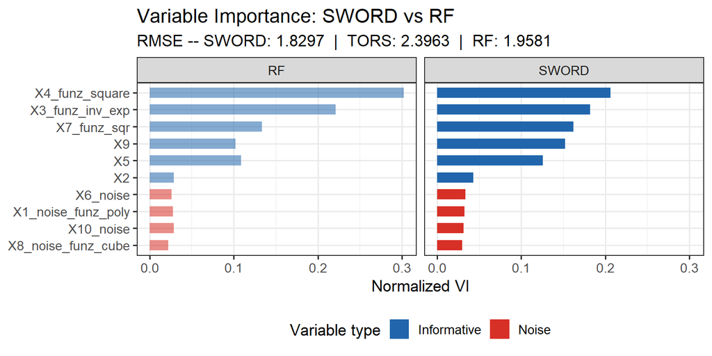

```r
vi_sword      <- VI_SWORD(sword_fit, parallel = FALSE)
vi_sword_norm <- vi_sword / sum(vi_sword)

vi_rf_norm    <- importance(rf_fit)[, "IncNodePurity"]
vi_rf_norm    <- vi_rf_norm / sum(vi_rf_norm)

make_vi_df <- function(vi_norm, model_label) {
  data.frame(
    variable = names(vi_norm),
    VI       = as.numeric(vi_norm),
    type     = ifelse(grepl("noise", names(vi_norm)), "Noise", "Informative"),
    model    = model_label
  )
}

vi_df          <- rbind(make_vi_df(vi_sword_norm, "SWORD"),
                        make_vi_df(vi_rf_norm,    "RF"))
var_order      <- names(sort(vi_sword_norm, decreasing = FALSE))
vi_df$variable <- factor(vi_df$variable, levels = var_order)

print(
  ggplot(vi_df, aes(x = variable, y = VI, fill = type, alpha = model)) +
    geom_bar(stat = "identity", position = position_dodge(width = 0.7), width = 0.6) +
    scale_fill_manual(values = c("Informative" = "#2166ac", "Noise" = "#d73027")) +
    scale_alpha_manual(values = c("SWORD" = 1, "RF" = 0.55)) +
    coord_flip() +
    facet_wrap(~ model, ncol = 2) +
    labs(
      title    = "Variable Importance: SWORD vs RF",
      subtitle = sprintf("RMSE -- SWORD: %.4f  |  TORS: %.4f  |  RF: %.4f",
                         rmse_sword, rmse_tors, rmse_rf),
      x = NULL, y = "Normalized VI",
      fill = "Variable type", alpha = "Model"
    ) +
    guides(alpha = "none") +
    theme_bw(base_size = 13) +
    theme(legend.position = "bottom")
)
```

## Parameter Tuning Guide

| Goal | Parameter to change |
| --- | --- |
| Deeper trees / more flexible model | Decrease `nmin` (e.g., 3) or `cp` (keep at 0) |
| Faster fitting | Decrease `m` (fewer trees) or enable `parallel = TRUE` |
| More randomness (lower correlation between trees) | Decrease `rf_var` or enable `rand_ntopcor = TRUE` |
| Robust to outliers | Set `Weight_Scheme = "robust"` |
| Use mutual information instead of correlation | Set `relation = "MI"` (requires `infotheo`) |
| Skip slow trees automatically | Set `timeout_tree = 60` (seconds) |
| Reproducibility | Fix `seed_BS` (controls all bootstrap draws) |

## Output Structure

[output not shown]

```r
cat("OOB MSE:", sword_fit$MSE, "\n")
```

```
## OOB MSE: 2.691799
```

Plot OOB MSE convergence as trees are added:

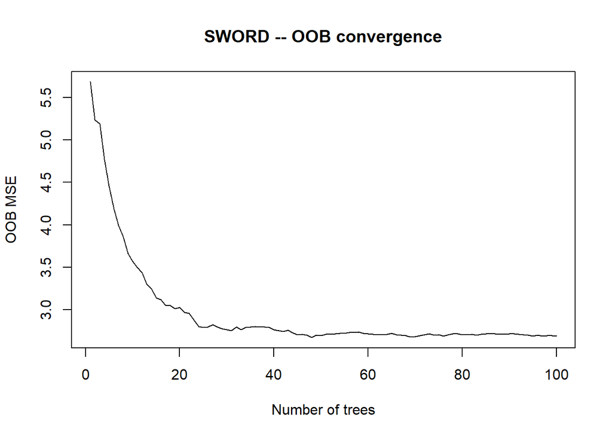

```r
plot(sword_fit$oob_errors_per_iter, type = "l",
     xlab = "Number of trees", ylab = "OOB MSE",
     main = "SWORD -- OOB convergence")
```

*Functions implemented in `SWORD_functions/SWORD_Functions_ADAC.R`.* *Paper: “Oblique Random Forests for Regression via Weighted Support Vector Machine”, submitted to ADAC (Manuscript ID: ADAC-D-25-00591).*